# Familia de origen de la Pareja y/o Agresor

ENRIQUE

19/7/2020

#ÁRBOLES DE CLASIFICACIÓN METODO CART Cargando la base de datos

```r
load("C:\\Users\\Dell\\Documents\\GitHub\\mi_proyecto1_EST_384\\proy_MineriaDatos\\bd_proy\\bd_sep.RData")
```

```r
levels(bd_sep$S3_13_1)
```

```
## [1] "1. Varias veces." "2. Una vez."      "3. No"
```

```r
levels(bd_sep$S3_12_1)
```

[output not shown]

variables de interes:

- area Area geografíca
- S2_5_1 ¿Durante su niñez, las personas con las que vivía, alguna vez a usted la insultaban o humillaban?
- S2_5_2 ¿Durante su niñez, las personas con las que vivía, alguna vez a usted la amenazaban con pegarla o echarla de la casa?
- S2_5_3 ¿Durante su niñez, las personas con las que vivía, alguna vez a usted la amenazaban con cuchillo o algún arma?
- S2_5_4 ¿Durante su niñez, las personas con las que vivía, alguna vez a usted la jaloneaban, sacudían, jalaban de su cabello o escupían?
- S2_5_5 ¿Durante su niñez, las personas con las que vivía, alguna vez a usted le daban sopapos, puñetazos o la pateaban?
- S2_5_6 ¿Durante su niñez, las personas con las que vivía, alguna vez a usted la golpeaban con algún objeto?
- S2_5_7 ¿Durante su niñez, las personas con las que vivía, alguna vez a usted la encerraban o no la dejaban salir?
- S3_10_01 ¿Desde que inició la relación con su (ex) pareja/ (ex) novio, alguna vez él la ha insultado, se dirigió a usted con palabras groseras o agresivas?
- S3_10_02 ¿Desde que inició la relación con su (ex) pareja/ (ex) novio, alguna vez él la ha avergonzado, menospreciado o humillado?
- S3_10_03 ¿Desde que inició la relación con su (ex) pareja/ (ex) novio, alguna vez él la ha encerrado, le ha prohibido salir o que la visiten?
- S3_10_04 ¿Desde que inició la relación con su (ex) pareja/ (ex) novio, alguna vez él la ha amenazado con lastimarla ?
- S3_10A_04 ¿Este hecho le pareció?
- S3_10B_04 ¿En los últimos 12 meses, esto ocurrió?
- S3_10_05 ¿Desde que inició la relación con su (ex) pareja/ (ex) novio, alguna vez él la ha amenazado con matarla?
- S3_10A_05 ¿Este hecho le pareció?
- S3_10B_05 ¿En los últimos 12 meses, esto ocurrió?
- S3_10_06 ¿Desde que inició la relación con su (ex) pareja/ (ex) novio, alguna vez él la ha amenazado con quitarle a sus hijos/as?
- S3_10A_06 ¿Este hecho le pareció?
- S3_10B_06 ¿En los últimos 12 meses, esto ocurrió?
- S3_10_07 ¿Desde que inició la relación con su (ex) pareja/ (ex) novio, alguna vez él aunque tenga dinero no cumple con los gastos del hogar?
- S3_10A_07 ¿Este hecho le pareció?
- S3_10B_07 ¿En los últimos 12 meses, esto ocurrió? *S3_10_08 ¿Desde que inició la relación con su (ex) pareja/ (ex) novio, alguna vez él le ha prohibido adquirir bienes o propiedades a su nombre?
- S3_10A_08 ¿Este hecho le pareció?
- S3_10B_08 ¿En los últimos 12 meses, esto ocurrió?
- S3_10_09 ¿Desde que inició la relación con su (ex) pareja/ (ex) novio, alguna vez él ha destruido, tirado o escondido sus cosas?
- S3_10A_09 ¿Este hecho le pareció?
- S3_10B_09 En los últimos 12 meses, esto ocurrió?
- S3_10_10 ¿Desde que inició la relación con su (ex) pareja/ (ex) novio, alguna vez él le ha quitado, o se ha adueñado de su dinero?
- S3_10A_10 ¿Este hecho le pareció?
- S3_10B_10 ¿En los últimos 12 meses, esto ocurrió?
- S3_10_11 ¿Desde que inició la relación con su (ex) pareja/ (ex) novio, alguna vez él le ha quitado, o se ha adueñado de sus bienes (cosas, terrenos, etc.)?
- S3_10A_11 ¿Este hecho le pareció?
- S3_10B_11 ¿¿En los últimos 12 meses, esto ocurrió?
- S3_10_12 ¿Desde que inició la relación con su (ex) pareja/ (ex) novio, alguna vez él la ha empujado o le ha jalado el cabello?
- S3_10A_12 ¿Este hecho le pareció?
- S3_10B_12 ¿En los últimos 12 meses, esto ocurrió?
- S3_10_13 ¿Desde que inició la relación con su (ex) pareja/ (ex) novio, alguna vez él la ha abofeteado, golpeado con las manos o puños?
- S3_10A_13 ¿Este hecho le pareció?
- S3_10B_13 ¿En los últimos 12 meses, esto ocurrió?
- S3_10_14 ¿Desde que inició la relación con su (ex) pareja/ (ex) novio, alguna vez él la ha golpeado con algún objeto?
- S3_10A_14 ¿Este hecho le pareció?
- S3_10B_14 ¿En los últimos 12 meses, esto ocurrió?
- S3_10_15 ¿Desde que inició la relación con su (ex) pareja/ (ex) novio, alguna vez él la ha pateado?
- S3_10A_15 ¿Este hecho le pareció?
- S3_10B_15 ¿En los últimos 12 meses, esto ocurrió?
- S3_10_16 ¿Desde que inició la relación con su (ex) pareja/ (ex) novio, alguna vez él la ha tratado de ahorcar o asfixiar?
- S3_10A_16 ¿Este hecho le pareció?
- S3_10B_16 ¿En los últimos 12 meses, esto ocurrió?
- S3_10_17 ¿Desde que inició la relación con su (ex) pareja/ (ex) novio, alguna vez él la ha amenazado con armas (cuchillo, navaja o pistola)?
- S3_10A_17 ¿Este hecho le pareció?
- S3_10B_17 ¿En los últimos 12 meses, esto ocurrió?
- S3_10_18 ¿Desde que inició la relación con su (ex) pareja/ (ex) novio, alguna vez él la ha agredido con cuchillo, navaja, pistola o cualquier otra arma?
- S3_10A_18 ¿Este hecho le pareció?
- S3_10B_18 ¿En los últimos 12 meses, esto ocurrió?
- S3_10_19 ¿Desde que inició la relación con su (ex) pareja/ (ex) novio, alguna vez él le ha disparado con un arma?
- S3_10A_19 ¿Este hecho le pareció?
- S3_10B_19 ¿En los últimos 12 meses, esto ocurrió?
- S3_10_20 ¿Desde que inició la relación con su (ex) pareja/ (ex) novio, alguna vez él ha usado la fuerza física para obligarla a tener relaciones sexuales?
- S3_10A_20 ¿Este hecho le pareció?
- S3_10B_20 ¿En los últimos 12 meses, esto ocurrió?
- S3_10_21 ¿Desde que inició la relación con su (ex) pareja/ (ex) novio, alguna vez él le ha exigido tener relaciones sexuales aunque usted no quería?
- S3_10A_21 ¿Este hecho le pareció?
- S3_10B_21 ¿En los últimos 12 meses, esto ocurrió?
- S3_10_22 ¿Desde que inició la relación con su (ex) pareja/ (ex) novio, alguna vez él cuando tienen relaciones sexuales la ha obligado a hacer cosas que a usted no le gusta?

obteniendo las variables

```r
library(dplyr)
aux3<-c(5,69,133,204,205,seq(206,218,2),seq(279,342,3))

bd_cart<-bd_sep %>% dplyr::select(aux3)
attributes(bd_cart)
```

[output not shown]

[output cut: 84 more lines]

```r
#levels(bd_cart$S3_13_4)
levels(bd_cart$S2_5_1)
```

```
## [1] "1. Muchas veces" "2. Pocas veces"  "3. Una vez"      "4. No ocurrió"
## [5] "5. No recuerda "
```

```r
aux4<-c("1. Muchas veces","2. Pocas veces","3. Una vez")

bd_cart<-bd_cart %>% mutate(violencia_infancia=S2_5_1
==aux4|S2_5_2==aux4|S2_5_3==aux4|S2_5_4==aux4|S2_5_5==aux4|S2_5_6==aux4|S2_5_1==aux4)

levels(bd_cart$S3_10_01)
```

```
## [1] "1. Muchas veces" "2. Pocas veces"  "3. Una vez"      "4. No ocurrió"
## [5] "5. No recuerda"  "6. No aplica"
```

```r
bd_cart<-bd_cart %>% mutate(pareja_violenta=S3_10_01==aux4|S3_10_02==aux4|S3_10_03==aux4|S3_10_04==aux4|S3_10_05==aux4|S3_10_06==aux4|S3_10_07==aux4|S3_10_08==aux4|S3_10_09==aux4|S3_10_10==aux4|S3_10_11==aux4|S3_10_12==aux4|S3_10_13==aux4|S3_10_14==aux4|S3_10_15==aux4|S3_10_16==aux4|S3_10_17==aux4|S3_10_18==aux4|S3_10_19==aux4|S3_10_20==aux4|S3_10_21==aux4|S3_10_22==aux4)


bd_cart<-bd_cart %>% dplyr::select(-c(6:34))

bd_cart<-bd_cart %>% rename(tutores_se_insultaban=S2_3)
#bd_cart<-bd_cart %>% dplyr::select(-no_denuncio)

#bd_cart<-bd_cart %>% dplyr::select(-c(7:11))

#bd_cart<-bd_cart %>% dplyr::select(-S3_11)
#bd_cart<-bd_cart %>% dplyr::select(-c(S2_7,S2_8))
bd_cart<-na.omit(bd_cart)
```

haciendo los pasos

```r
library(rpart)
str(bd_cart)
```

```
## 'data.frame':    1213 obs. of  7 variables:
##  $ area                 : Factor w/ 2 levels "urbano","Rural": 1 1 1 1 1 1 1 1 1 1 ...
##  $ S1_10                : Factor w/ 2 levels "1. SI","2. NO": 2 2 2 2 1 1 2 2 1 1 ...
##  $ S1_20                : Factor w/ 2 levels "1. Si","2. No": 1 1 1 1 1 1 2 2 1 1 ...
##  $ tutores_se_insultaban: Factor w/ 5 levels "1. Muchas veces",..: 5 1 2 1 1 2 4 2 2 2 ...
##  $ S2_4                 : Factor w/ 5 levels "1. Muchas veces",..: 5 1 4 2 2 4 4 5 3 5 ...
##  $ violencia_infancia   : logi  FALSE TRUE FALSE FALSE TRUE FALSE ...
##  $ pareja_violenta      : logi  FALSE TRUE FALSE FALSE FALSE TRUE ...
```

```r
bd_cart$violencia_infancia<-factor(bd_cart$violencia_infancia,c(T,F),labels = c("violencia_infancia","no_violencia_infancia"))

bd_cart$pareja_violenta<-factor(bd_cart$pareja_violenta,c(T,F),labels = c("pareja_violenta","no_pareja_violenta"))
```

bases de entrenamiento y test

```r
## Bases: trainbd, testbd
set.seed(123)
index = sample(1:2, nrow(bd_cart), replace = TRUE, prob=c(0.7, 0.3))
prop.table(table(index))
```

```
## index
##         1         2
## 0.7056884 0.2943116
```

```r
trainbd<-bd_cart[index==1,]
testbd<-bd_cart[index==2,]

mod1<-rpart(pareja_violenta~.,data=trainbd)

mod1
```

```
## n= 856
##
## node), split, n, loss, yval, (yprob)
##       * denotes terminal node
##
## 1) root 856 333 pareja_violenta (0.6109813 0.3890187)
##   2) violencia_infancia=violencia_infancia 347  72 pareja_violenta (0.7925072 0.2074928) *
##   3) violencia_infancia=no_violencia_infancia 509 248 no_pareja_violenta (0.4872299 0.5127701)
##     6) tutores_se_insultaban=1. Muchas veces,2. Pocas veces,3. Una vez 312 137 pareja_violenta (0.5608974 0.4391026) *
##     7) tutores_se_insultaban=4. No ocurrió,5. No recuerda 197  73 no_pareja_violenta (0.3705584 0.6294416) *
```

Examinando los parámetros del árbol con printcp

```r
printcp(mod1)
```

```
##
## Classification tree:
## rpart(formula = pareja_violenta ~ ., data = trainbd)
##
## Variables actually used in tree construction:
## [1] tutores_se_insultaban violencia_infancia
##
## Root node error: 333/856 = 0.38902
##
## n= 856
##
##         CP nsplit rel error  xerror     xstd
## 1 0.076577      0   1.00000 1.00000 0.042834
## 2 0.010000      2   0.84685 0.87387 0.041619
```

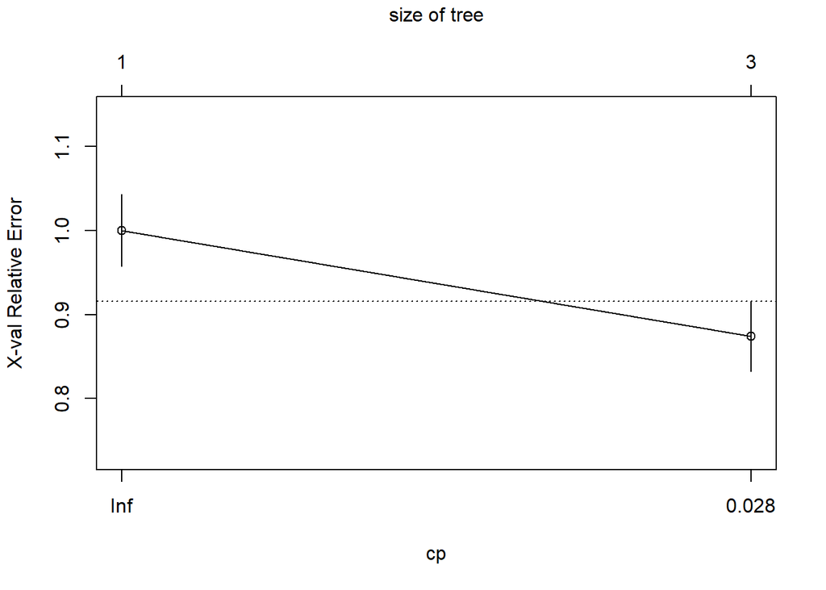

```r
plotcp(mod1)
```

```r
#examinando el modelo

summary(mod1)
```

```
## Call:
## rpart(formula = pareja_violenta ~ ., data = trainbd)
##   n= 856
##
##           CP nsplit rel error    xerror       xstd
## 1 0.07657658      0 1.0000000 1.0000000 0.04283432
## 2 0.01000000      2 0.8468468 0.8738739 0.04161880
##
## Variable importance
##    violencia_infancia tutores_se_insultaban                  S2_4
##                    68                    19                    12
##
## Node number 1: 856 observations,    complexity param=0.07657658
##   predicted class=pareja_violenta     expected loss=0.3890187  P(node) =1
##     class counts:   523   333
##    probabilities: 0.611 0.389
##   left son=2 (347 obs) right son=3 (509 obs)
##   Primary splits:
##       violencia_infancia    splits as  LR,    improve=38.4585300, (0 missing)
##       tutores_se_insultaban splits as  LLLRR, improve=18.1560400, (0 missing)
##       S2_4                  splits as  LLRRR, improve=10.6441100, (0 missing)
##       S1_20                 splits as  LR,    improve= 1.7307460, (0 missing)
##       S1_10                 splits as  LR,    improve= 0.4697809, (0 missing)
##   Surrogate splits:
##       tutores_se_insultaban splits as  LRRRR, agree=0.616, adj=0.052, (0 split)
##       S2_4                  splits as  LRRRR, agree=0.612, adj=0.043, (0 split)
##
## Node number 2: 347 observations
##   predicted class=pareja_violenta     expected loss=0.2074928  P(node) =0.4053738
##     class counts:   275    72
##    probabilities: 0.793 0.207
##
## Node number 3: 509 observations,    complexity param=0.07657658
##   predicted class=no_pareja_violenta  expected loss=0.4872299  P(node) =0.5946262
##     class counts:   248   261
##    probabilities: 0.487 0.513
##   left son=6 (312 obs) right son=7 (197 obs)
##   Primary splits:
##       tutores_se_insultaban splits as  LLLRR, improve=8.7496140, (0 missing)
##       S2_4                  splits as  RLRRR, improve=3.4513320, (0 missing)
##       S1_10                 splits as  LR,    improve=0.7960010, (0 missing)
##       S1_20                 splits as  LR,    improve=0.3190903, (0 missing)
##       area                  splits as  RL,    improve=0.1475482, (0 missing)
##   Surrogate splits:
##       S2_4  splits as  LLLRR, agree=0.837, adj=0.579, (0 split)
##       S1_20 splits as  LR,    agree=0.623, adj=0.025, (0 split)
##
## Node number 6: 312 observations
##   predicted class=pareja_violenta     expected loss=0.4391026  P(node) =0.364486
##     class counts:   175   137
##    probabilities: 0.561 0.439
##
## Node number 7: 197 observations
##   predicted class=no_pareja_violenta  expected loss=0.3705584  P(node) =0.2301402
##     class counts:    73   124
##    probabilities: 0.371 0.629
```

visualizar el arbol

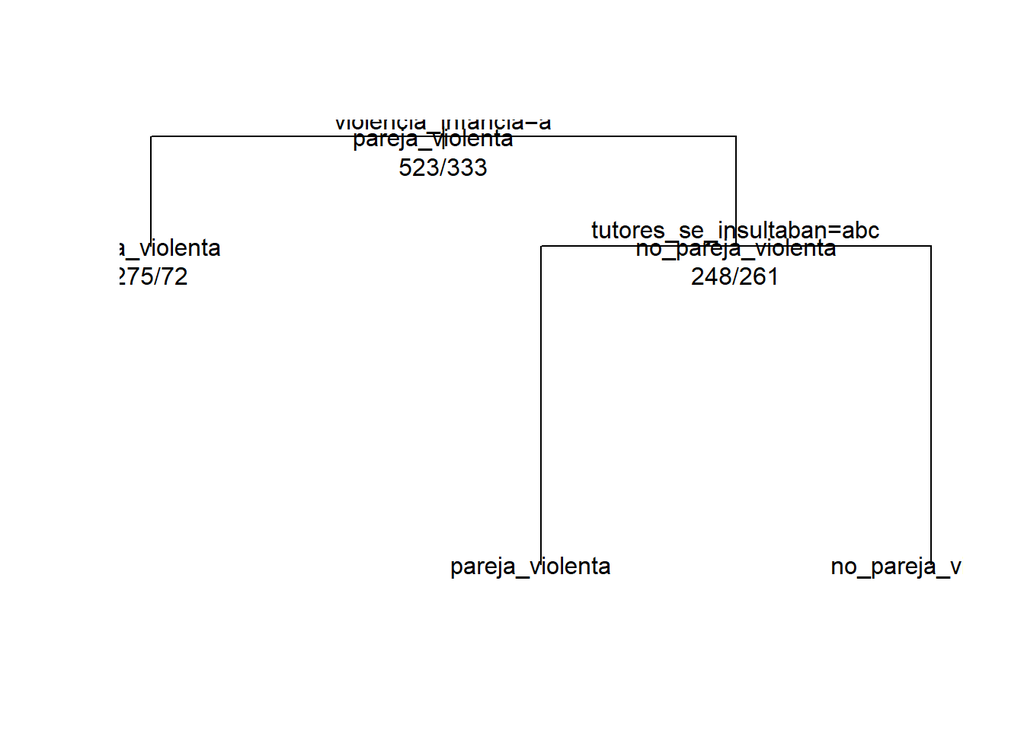

```r
plot(mod1)
text(mod1,all=T,use.n=T)
```

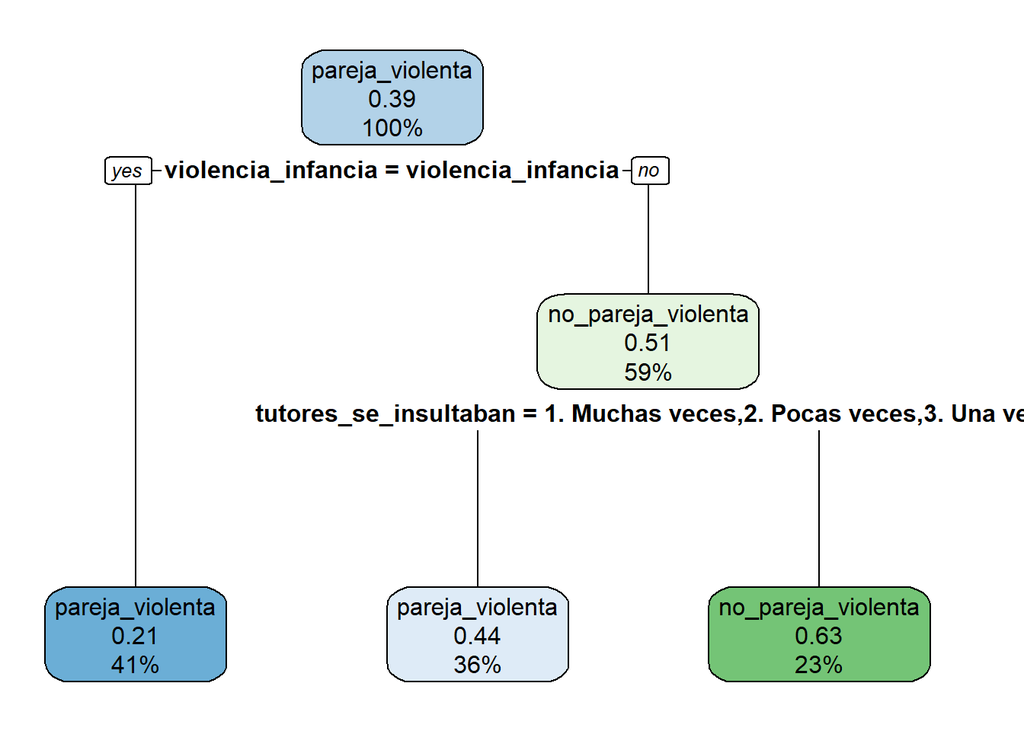

```r
#install.packages("rpart.plot")
library(rpart.plot)
rpart.plot(mod1)
```

Predicción de la clasificación predict(…, testbd, type=“class”), predicción sobre la base de test

```r
clase<-predict(mod1,testbd,type = "class")
```

10. Elaborar una tabla de contingencia de la clasificación

```r
table(clase,testbd$pareja_violenta)
```

```
##
## clase                pareja_violenta no_pareja_violenta
##   pareja_violenta                160                110
##   no_pareja_violenta              29                 58
```

11. Emplear el comando confusionMatrix sobre la tabla del paso anterior, para evaluar la calidad de la clasificación. Mcnemar’s Test H0: $ij=ji$

```r
library(caret)
confusionMatrix(table(clase,testbd$pareja_violenta))
```

```
## Confusion Matrix and Statistics
##
##
## clase                pareja_violenta no_pareja_violenta
##   pareja_violenta                160                110
##   no_pareja_violenta              29                 58
##
##                Accuracy : 0.6106
##                  95% CI : (0.5579, 0.6615)
##     No Information Rate : 0.5294
##     P-Value [Acc > NIR] : 0.001197
##
##                   Kappa : 0.1971
##
##  Mcnemar's Test P-Value : 1.157e-11
##
##             Sensitivity : 0.8466
##             Specificity : 0.3452
##          Pos Pred Value : 0.5926
##          Neg Pred Value : 0.6667
##              Prevalence : 0.5294
##          Detection Rate : 0.4482
##    Detection Prevalence : 0.7563
##       Balanced Accuracy : 0.5959
##
##        'Positive' Class : pareja_violenta
##
```